# Introducción a R

Primeros pasos

Esteban Arroyo

31-07-2023

# Esta es una guía básica de los primeros pasos en R

### Una vez realizada la correcta Instalación de R, procedemos a realizar algunas operaciones básicas: Funciona como una calculadora

```r
1+1     #Podemos sumar
```

```
## [1] 2
```

```r
10-6    #Podemos restar
```

```
## [1] 4
```

```r
7*4     #Podemos multiplicar
```

```
## [1] 28
```

```r
12/3    #Podemos dividir
```

```
## [1] 4
```

```r
5^2     #Podemos elevar a la potencia de un número
```

```
## [1] 25
```

```r
sqrt(36) #Podemos obtener la raiz cuadrada, entre otras opraciones
```

```
## [1] 6
```

### Podemos crear secuencias y vectores

```r
1:10         # Esto crea una secuencia de números entreros del 1 al 10 de forma ascendente
```

```
##  [1]  1  2  3  4  5  6  7  8  9 10
```

```r
10:1         # Esto crea una secuencia de números entreros del 1 al 10 de forma descendente
```

```
##  [1] 10  9  8  7  6  5  4  3  2  1
```

```r
-25:-15      # Crea una secuencia de números enteros entre -25 y -15
```

```
##  [1] -25 -24 -23 -22 -21 -20 -19 -18 -17 -16 -15
```

```r
3.5:10      #Crea una secuencia de números decimales entre 3.5 a 9.5
```

```
## [1] 3.5 4.5 5.5 6.5 7.5 8.5 9.5
```

```r
seq(from=1, to=5, by=0.5)    #Con la función seq(), crea una secuencia de números del 1 al 5 con intervalos de 0.5
```

```
## [1] 1.0 1.5 2.0 2.5 3.0 3.5 4.0 4.5 5.0
```

```r
seq(1,10,0.2)   #Con la función seq(), crea una secuencia de números del 1 al 10 con intervalos de 0.2
```

```
##  [1]  1.0  1.2  1.4  1.6  1.8  2.0  2.2  2.4  2.6  2.8  3.0  3.2  3.4  3.6  3.8
## [16]  4.0  4.2  4.4  4.6  4.8  5.0  5.2  5.4  5.6  5.8  6.0  6.2  6.4  6.6  6.8
## [31]  7.0  7.2  7.4  7.6  7.8  8.0  8.2  8.4  8.6  8.8  9.0  9.2  9.4  9.6  9.8
## [46] 10.0
```

```r
x <- 1:10       #De esta forma guardamos la secuencia en un objeto llamado vector
z <- c(1,2,3,4,5)         #la función c() (combinar) Permite crear vectores
y <- c("a","b","c","d")   #la función c() (combinar) Permite crear vectores

x    #Visualizamos el contenido del vector
```

```
##  [1]  1  2  3  4  5  6  7  8  9 10
```

```r
z    #Visualizamos el contenido del vector
```

```
## [1] 1 2 3 4 5
```

```r
y    #Visualizamos el contenido del vector
```

```
## [1] "a" "b" "c" "d"
```

### Verificamos si son un vector con la función is.vector()

```r
is.vector(x)
```

```
## [1] TRUE
```

```r
is.vector(z)
```

```
## [1] TRUE
```

```r
is.vector(y)
```

```
## [1] TRUE
```

### Usamos la función length() para conocer su largo

```r
length(x)
```

```
## [1] 10
```

```r
length(z)
```

```
## [1] 5
```

```r
length(y)
```

```
## [1] 4
```

### Con la función class() verificamos el tipo de vector

```r
class(x)
```

```
## [1] "integer"
```

```r
class(z)
```

```
## [1] "numeric"
```

```r
class(y)
```

```
## [1] "character"
```

### Con mode() verificamos el “tipo” de datos en el vector. Es el modo de almacenamiento de un objeto R

```r
mode(x)
```

```
## [1] "numeric"
```

```r
mode(z)
```

```
## [1] "numeric"
```

```r
mode(y)
```

```
## [1] "character"
```

### Juntar vectores

```r
mi_vector_1 <- c(1,2,3,4)
mi_vector_2 <- c(5,6,7,8)

mi_vector_3 <- c(mi_vector_1, mi_vector_2)
mi_vector_3
```

```
## [1] 1 2 3 4 5 6 7 8
```

### Operar sobre un vector <- Operación se realiza sobre cada elemento del vector. Tambien se conoce como vectorización de operaciones

```r
mi_vector_1 + 1
```

```
## [1] 2 3 4 5
```

```r
mi_vector_2 - 1
```

```
## [1] 4 5 6 7
```

```r
mi_vector_3 * 2
```

```
## [1]  2  4  6  8 10 12 14 16
```

```r
mi_vector_3 / 2
```

```
## [1] 0.5 1.0 1.5 2.0 2.5 3.0 3.5 4.0
```

## Matrices

### Una matriz en R es un conjunto de objetos indizados por filas y columnas (Dos dimensiones). Se usa la función matrix(data, nrow, ncol, byrow=F)

```r
matrix(1:15)                 #Al no especificarse nada, se crea un vector columna
```

```
##       [,1]
##  [1,]    1
##  [2,]    2
##  [3,]    3
##  [4,]    4
##  [5,]    5
##  [6,]    6
##  [7,]    7
##  [8,]    8
##  [9,]    9
## [10,]   10
## [11,]   11
## [12,]   12
## [13,]   13
## [14,]   14
## [15,]   15
```

```r
matrix(1:15, nrow=5, ncol=3) #Se crea una matriz con 5 filas y 3 columnas
```

```
##      [,1] [,2] [,3]
## [1,]    1    6   11
## [2,]    2    7   12
## [3,]    3    8   13
## [4,]    4    9   14
## [5,]    5   10   15
```

```r
matrix(1:15, nrow=3, ncol=3) #Se crea una matriz con 3 filas y 3 columnas. Se omiten los datos que no caben en la matriz
```

```
##      [,1] [,2] [,3]
## [1,]    1    4    7
## [2,]    2    5    8
## [3,]    3    6    9
```

```r
matrix(1:12, 3, 4)           #se crea una matriz 3 filas y 4 columnas
```

```
##      [,1] [,2] [,3] [,4]
## [1,]    1    4    7   10
## [2,]    2    5    8   11
## [3,]    3    6    9   12
```

```r
matrix(1:12, 3, 4, byrow=TRUE) #Cambiamos el orden en que se leen los datos, ahora por filas
```

```
##      [,1] [,2] [,3] [,4]
## [1,]    1    2    3    4
## [2,]    5    6    7    8
## [3,]    9   10   11   12
```

```r
ejemplo <- matrix(c(2,8,33,19,22,16,6,4), ncol=4) #aquí solo especificamos 4 columnas y automaticamente me genera 2 filas
ejemplo
```

```
##      [,1] [,2] [,3] [,4]
## [1,]    2   33   22    6
## [2,]    8   19   16    4
```

### Con cbind() y rbind() podemos crear matrices con la unión de varios vectores

### cbind() para unir vectores, usando cada uno como una columna

### rbind() para unir vectores, usando cada uno como un renglón

```r
# Primero creamos los vectores
vector_4 <- 1:4
vector_5 <- 5:8
vector_6 <- 9:12

# Luego usamos rbind() para crear un matriz, en la que cada vector será una fila
matriz <- rbind(vector_4, vector_5, vector_6)
matriz
```

```
##          [,1] [,2] [,3] [,4]
## vector_4    1    2    3    4
## vector_5    5    6    7    8
## vector_6    9   10   11   12
```

```r
# Si utilizamos cbind(), entonces cada vector será una columna
matriz <- cbind(vector_4, vector_5, vector_6)
matriz
```

```
##      vector_4 vector_5 vector_6
## [1,]        1        5        9
## [2,]        2        6       10
## [3,]        3        7       11
## [4,]        4        8       12
```

### Podemos verificar las dimensiones de la matriz

```r
mi_matriz <- matrix(1:12, 3, 4)

dim(mi_matriz)
```

```
## [1] 3 4
```

```r
dim(matriz)
```

```
## [1] 4 3
```

### Poner nombre a las filas y columnas de las matriz

```r
ejem <- matrix(c(2,8,33,19), ncol=2)
ejem
```

```
##      [,1] [,2]
## [1,]    2   33
## [2,]    8   19
```

```r
dimnames(ejem)<- list(c("Individuo 1","Individuo 2"), c("Hermanos","Edad")) #la función list() nos permite crear lista de caracteres
ejem
```

```
##             Hermanos Edad
## Individuo 1        2   33
## Individuo 2        8   19
```

### Con colnames(), para cambiar el nombre de las columnas

```r
colnames(ejem)<- c("Bro", "Age")
ejem
```

```
##             Bro Age
## Individuo 1   2  33
## Individuo 2   8  19
```

### Con rownames(), para cambiar el nombre de las filas

```r
rownames(ejem)<- c("Ind1", "Ind2")
ejem
```

```
##      Bro Age
## Ind1   2  33
## Ind2   8  19
```

### Para operar sobre una matriz

```r
mi_primera_matriz <- matrix(1:12,3,4)  #vectorizo mi matriz
mi_primera_matriz
```

```
##      [,1] [,2] [,3] [,4]
## [1,]    1    4    7   10
## [2,]    2    5    8   11
## [3,]    3    6    9   12
```

```r
mi_primera_matriz+1  # A todos los elementos de la matriz se les ha sumado 1
```

```
##      [,1] [,2] [,3] [,4]
## [1,]    2    5    8   11
## [2,]    3    6    9   12
## [3,]    4    7   10   13
```

```r
mi_primera_matriz*2  # A todos los elementos de la matriz se les multiplica por 2
```

```
##      [,1] [,2] [,3] [,4]
## [1,]    2    8   14   20
## [2,]    4   10   16   22
## [3,]    6   12   18   24
```

```r
mi_primera_matriz^3  # A todos los elementos de la matriz se eleva al cubo
```

```
##      [,1] [,2] [,3] [,4]
## [1,]    1   64  343 1000
## [2,]    8  125  512 1331
## [3,]   27  216  729 1728
```

### Usamos t() para transponer

```r
matriz_t <- t(matriz)
matriz_t
```

```
##          [,1] [,2] [,3] [,4]
## vector_4    1    2    3    4
## vector_5    5    6    7    8
## vector_6    9   10   11   12
```

## Data frames

### Los data frames son estructuras de datos de dos dimensiones (rectangulares). Pueden contener datos de diferentes tipos, por lo tanto, son heterogéneas. Esta estructura de datos es la más usada para realizar análisis de datos. Podemos entender a los data frames como una versión más flexible de una matriz. Mientras que en una matriz todas las celdas deben contener datos del mismo tipo, los renglones de un data rame admiten datos de distintos tipos pero sus columnas conservan la restricción de contener datos de un sólo tipo En términos generales, los renglones en un data frame representan casos, individuos u observaciones, mientras que las columnas representan atributos, rasgos o variables

### Para crear un data frame usamos la función data.frame()

### Esta función nos pedirá un número de vectores igual al número de columnas que deseemos. Esto es muy importante: Un data frame está compuesto por vectores. Podemos asignar un nombre a cada vector, que se convertirá en el nombre de la columna.

```r
dataframe <- data.frame("secuencia"=1:4, "letra"=c("a","b","c","d"), "numero"=c(1.2,3.4,4.5,5.6)) #Se ha vectorizado el dataframe
dataframe
```

```
##   secuencia letra numero
## 1         1     a    1.2
## 2         2     b    3.4
## 3         3     c    4.5
## 4         4     d    5.6
```

## Creamos nuestro primer data frame

```r
mi_primer_dataframe <- data.frame(
  "sexo_a"=c("fem", "mas",  "fem",  "mas",  "mas",  "fem"),
  "edad_a"=c(30, 18,    20, 21, 20, 30),
  "Long_max_hum"=c(289, 295.5, 290.2, 292,  298, 284.8),
  "Diam_ver_cab_hum"=c(15.4, 14.5, 16.2, 15.9,  16.6, 14.8),
  "Diam_hor_cab_hum"=c(14.6, 13.5, 16,  14.3, 16, 14.2))
mi_primer_dataframe
```

```
##   sexo_a edad_a Long_max_hum Diam_ver_cab_hum Diam_hor_cab_hum
## 1    fem     30        289.0             15.4             14.6
## 2    mas     18        295.5             14.5             13.5
## 3    fem     20        290.2             16.2             16.0
## 4    mas     21        292.0             15.9             14.3
## 5    mas     20        298.0             16.6             16.0
## 6    fem     30        284.8             14.8             14.2
```

## Probamos diferentes propiedades del data frame

```r
#largo = N de columnas
length(mi_primer_dataframe)
```

```
## [1] 5
```

```r
#Cantidad de filas
nrow(mi_primer_dataframe)
```

```
## [1] 6
```

```r
#nombre de columnas
names(mi_primer_dataframe)
```

```
## [1] "sexo_a"           "edad_a"           "Long_max_hum"     "Diam_ver_cab_hum"
## [5] "Diam_hor_cab_hum"
```

```r
# Podemos usar dim() en un data frame para conocer las dimensiones (filas x columnas)
dim(mi_primer_dataframe)
```

```
## [1] 6 5
```

```r
# La clase de un data frame es data.frame
class(mi_primer_dataframe)
```

```
## [1] "data.frame"
```

## Coercionar matriz a data frame

## En R, los datos pueden ser coercionados, es decir, forzados, para transformarlos de un tipo a otro.

```r
a <- matrix(1:20, ncol=4)
a
```

```
##      [,1] [,2] [,3] [,4]
## [1,]    1    6   11   16
## [2,]    2    7   12   17
## [3,]    3    8   13   18
## [4,]    4    9   14   19
## [5,]    5   10   15   20
```

```r
as.data.frame(a) #Aqui se produce la coerción
```

```
##   V1 V2 V3 V4
## 1  1  6 11 16
## 2  2  7 12 17
## 3  3  8 13 18
## 4  4  9 14 19
## 5  5 10 15 20
```

```r
b <- matrix(1:20, ncol=5)
b
```

```
##      [,1] [,2] [,3] [,4] [,5]
## [1,]    1    5    9   13   17
## [2,]    2    6   10   14   18
## [3,]    3    7   11   15   19
## [4,]    4    8   12   16   20
```

```r
dataframe_b <- as.data.frame(b) #Aquí la coerción la hemos vectorizado
dataframe_b
```

```
##   V1 V2 V3 V4 V5
## 1  1  5  9 13 17
## 2  2  6 10 14 18
## 3  3  7 11 15 19
## 4  4  8 12 16 20
```

## Paquetes o Librerías

### R puede ser expandido con paquetes o librerías. Cada paquete es una colección de funciones diseñadas para atender una tarea específica. Por ejemplo, hay paquetes para trabajo visualización de datos (graficos), análisis psicométricos, mineria de datos, interacción con servicios de internet y muchas otras cosas más.

### Estos paquetes se encuentran alojados en CRAN (The Comprehensive R Archive Network, es un repositorio de R), así que pasan por un control riguroso antes de estar disponibles para su uso generalizado.

### Podemos instalar paquetes usando la función install.packages(), dando como argumento el nombre del paquete que deseamos instalar, entre comillas.

## Por ejemplo, para instalar el paquete dplyr, corremos lo siguiente.

```r
install.packages("dplyr")
```

### Hecho esto, apareceran algunos mensajes en la consola mostrando el avance de la instalación

### Una vez concluida la instalación de un paquete, podrás usar sus funciones con la función library(). Sólo tienes que llamar esta función usando como argumento el nombre del paquete que quieres utilizar, por ejemplo:

```r
library(dplyr)
```

### El paquete dplyr contiene una colección de funciones para realizar operaciones de manipulación de datos

### Algunas de las principales funciones son:

### select: devuelve un conjunto de columnas

### filter: devuelve un conjunto de filas según una o varias condiciones lógicas

### arrange: reordena filas de un data frame

### rename: renombra variables en una data frame

### mutate: añade nuevas variables/columnas o transforma variables existentes

### summarise/summarize: genera resúmenes estadísticos de diferentes variables en el data frame

### _%>% : el operador “pipe” es usado para conectar múltiples acciones en una única “pipeline” (tubería)

### Con help() pueden consultar ayuda/información de cualquier paquete o función. Por ejemplo:

```r
help("dplyr-package")  #Aquí pedimos información de paquete
help("rename")         #Aquí pedimos información de una función del paquete (se explica sintaxis y ejemplos)
?rename  #alternativamente puedes usar "?" para consultar sobre el paquete o función
```

### Pueden consultar esta página en español con más detalles de este paquete –> https://rsanchezs.gitbooks.io/rprogramming/content/chapter9/dplyr.html

### Con la función rename podemos cambiar los nombres de las columnas del data frame. Por ejemplo:

```r
rename(dataframe_b, I=V1, II=V2, III=V3, IV=V4, V=V5)  #Aquí la columna llamada V1, la renombramos como I, a la V2, como II, y así sucesivamente
```

```
##   I II III IV  V
## 1 1  5   9 13 17
## 2 2  6  10 14 18
## 3 3  7  11 15 19
## 4 4  8  12 16 20
```

## Importar una base de datos o fichero de datos

### NOTA: Casi todas base de datos importadas se cargan como un data frame. Para verificar esto usamos la función class()

### Mediante interfaz gráfica de R Studio

[figure not shown]

### Seleccionamos el boton “Import Dataset”

### Se desplega un menú con una serie de opciones. Si queremos importar un fichero de Excel, seleccionamos “From Excel…”

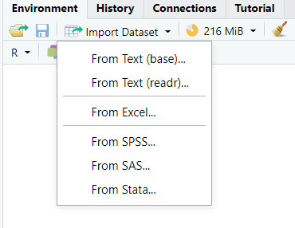

### Se abre una nueva ventana donde buscamos el fichero de excel que necesitamos importar. Para eso usamos el boton “Browse…”

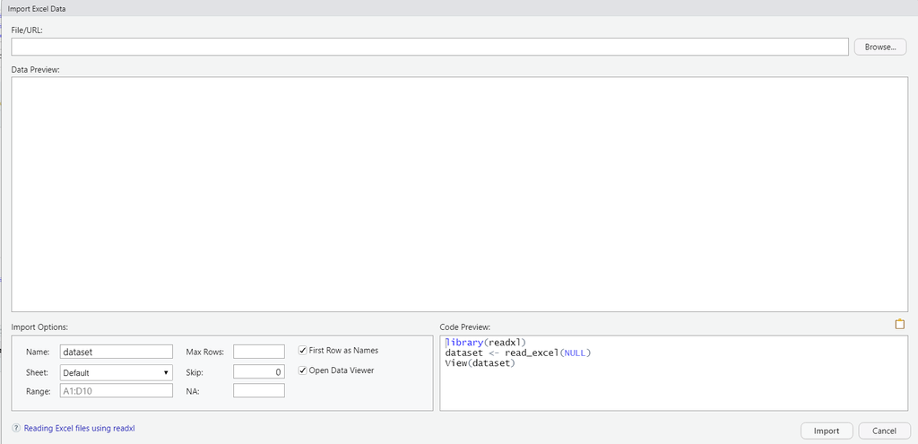

### Posteriormente en “Data preview” se previsualiza la data y revisamos si está correcto. De no ser así, podemos hacer ajustes como por ejemplo si la primera fila contiene los nombre de las columnas (First Row as Names). De forma predeterminada el porgrama lee la primera hoja de excel, pero si tenemos más de una hoja con datos, pordemos indicarle cuál hoja queremos que abra (Sheet).

### Si estamos conformes, apretamos el boton “Import”

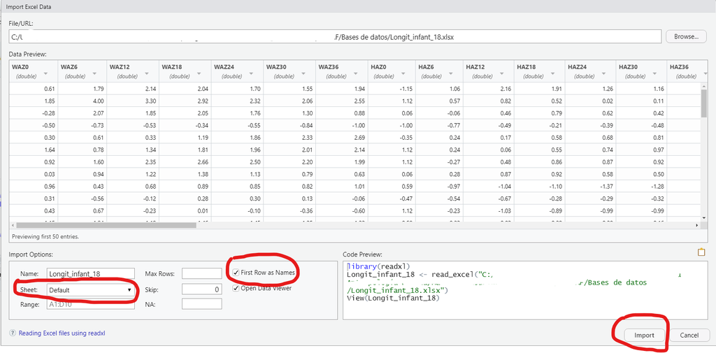

### En la pestaña “Environment” podemos ver que se ha cargado la base de datos. Donde indica que tenemos una base con 1000 filas y 49 columnas o variables

[figure not shown]

### Verificamos si esta base es un Data Frame

```r
class(Longit_infant_18)
```

[output not shown]

### Importar una base de excel usando el paquete de readxl y script

```r
install.packages("readxl")  #Instalamos el paquete que nos permite leer fichero de excel
```

### Cargamos el fichero con library()

```r
library(readxl)
```

### Importamos el fichero de excel

```r
data_set<-read_excel("Longit_infant_18.xlsx", sheet="in")  #Aquí la base se ha vectorizado en un nuevo objeto que hemos llamado data_set
```

### Verificamos en el “Environment” que aparezca la base llamada data_set

[figure not shown]

### Luego podemos visualizarla con la función View()

```r
View(data_set)
```

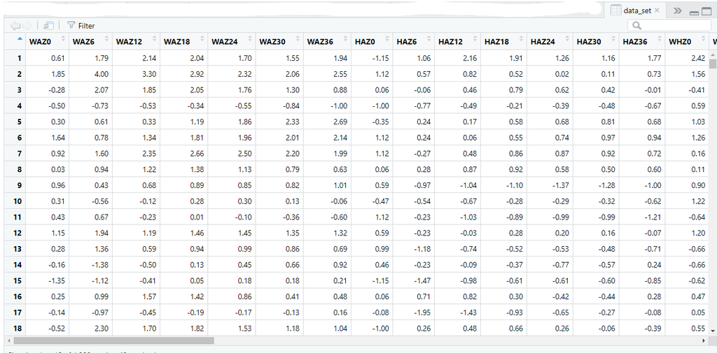

### Igualmente verificamos si esta base es una data frame

```r
class(data_set)
```

```
## [1] "tbl_df"     "tbl"        "data.frame"
```

### Tambien podemos importar una base .csv con la función read.csv

```r
mydata <- read.csv("Longit_infant_1.csv", sep=",", header=TRUE, fill = TRUE)  #Aqui tambien lo hemos vectorizado en un objeto
```

### La sixtasis básica es la siguiente:

### read.csv(file, # Nombre del archivo o ruta completa del archivo

### header = TRUE, # Leer el encabezado (TRUE) o no (FALSE)

### sep = “,”, # Separador de los valores

### quote = “"”, # Caracter de citaciones

### dec = “.”, # Punto decimal

### fill = TRUE, # Rellenar celdas vacías (TRUE) o no (FALSE)

### comment.char = "", # Carácter de los comentarios o cadenas vacías

### encoding = “unknown”, # Codificación del archivo

### …) # Argumentos adicionales

### Luego verificamos que se ubique en nuestro “Environment”

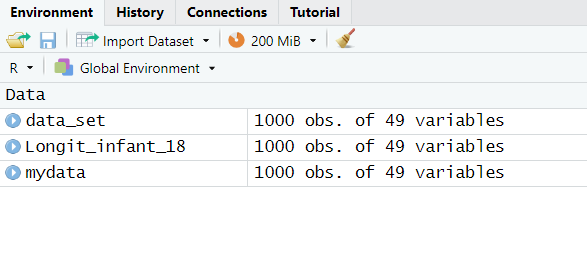

### Revisamos si es un data frame

```r
class(mydata)
```

```
## [1] "data.frame"
```

### finalmente hacemos in View()

```r
View(mydata)
```

### Tambien podemos importar un fichero csv desde la interfaz gráfica de R Studio en Import Dataset –> From Text (base). Luego buscamos el fichero .csv y ajustamos algunos parámetros como si los datos tienen encabezado (Heading) y si el separador es coma o punto y coma, entre otras (Separator). Si estamos conforme con la vizualización, presionamos “Import”.

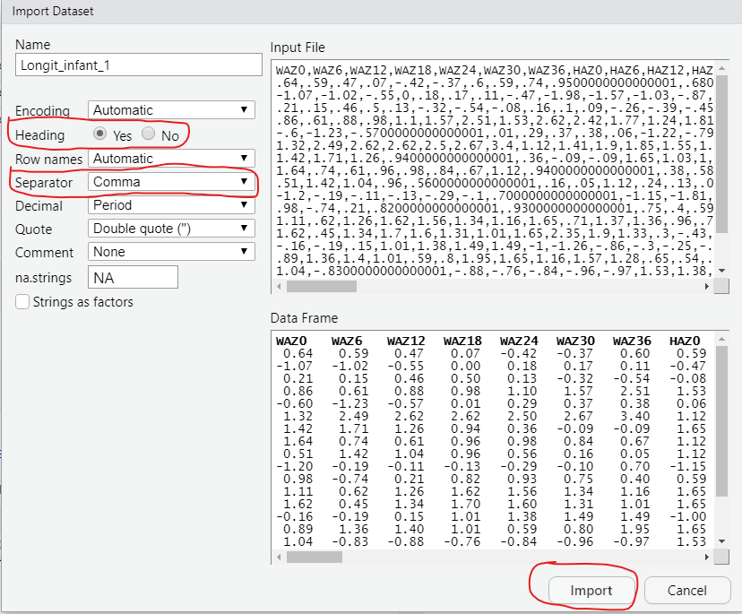

### Finalmente hacemos las verificaciones respectivas que hicimos en los casos anteriores

## IMPORTAR UNA BASE DE DATOS DESDE LA WEB

### Hacemos uso del Web scraping. Para ellos usamos las librerías tidyverse y rvest

```r
library(tidyverse)
library(rvest)
```

### Luego vectorizamos le dirección web de interes (wikipedia) en un objeto que llamamos url_wiki

```r
url_wiki <- ("https://en.wikipedia.org/wiki/Blood_type_distribution_by_country#ABO_and_Rh_distribution_by_country")
```

### Creamos un nuevo objeto llamado “tablas”, que tendrá todos los elementos que tengan el identificador table de la página web. Por lo tanto, el objeto será una lista de data.frames

```r
tablas <- url_wiki %>% read_html() %>% html_nodes("table") %>% html_table(fill = TRUE)
```

```r
Blood_type <- tablas[[2]] #El segundo data frame contiene la tabla que necesitamos
```

```r
head(Blood_type)  #hacemos un preview de nuestro nuevo data frame
```

```
## # A tibble: 6 x 10
##   `Country/Dependency` Populat~1 `O+`  `A+`  `B+`  `AB+` `O-`  `A-`  `B-`  `AB-`
##   <chr>                <chr>     <chr> <chr> <chr> <chr> <chr> <chr> <chr> <chr>
## 1 Albania[2]           3,074,579 34.1% 31.2% 14.5% 5.2%  6.0%  5.5%  2.6%  0.9%
## 2 Algeria[3]           43,576,6~ 40.0% 30.0% 15.0% 4.25% 6.6%  2.3%  1.1%  0.75%
## 3 Argentina[4]         45,479,1~ 48.9% 31.5~ 8.0%  2.45% 4.9%  3.16% 0.8%  0.25%
## 4 Armenia[5]           3,021,324 29.0% 46.3% 12.0% 5.6%  2.0%  3.7%  1.0%  0.4%
## 5 Australia[6]         25,466,4~ 38.0% 32.0% 12.0% 4.0%  7.0%  6.0%  2.0%  1.0%
## 6 Austria[7]           8,859,449 30.0% 37.0% 12.0% 5.0%  6.0%  7.0%  2.0%  0.45%
## # ... with abbreviated variable name 1: `Population[1]`
```

### Luego queda editar los datos para que los podamos usar. Pero eso lo veremos más adelante

## Para finalizar, podemos guardar nuestra base de datos en un fichero csv o excel si es que realizamos modificaciones (limpieza de datos o agregamos columnas nuevas, porducto de nuevos clalculos o transformaciones)

### Exportar los datos (data frame) como csv. Separador coma y punto como decimal

```r
write.csv(data_set, "nueva_ data_set.csv") #Se puede usar write.csv2() para separador punto y coma y coma como decimal
```

### Para exportarlo como fichero de Excel

```r
openxlsx::write.xlsx(data_set, file="data_set.xlsx")  #Si ya tienen previamente instalado el paquete openxlsx, podemos llamar su función directamente de esta forma
```